# SY19 - TP note - Regression et classification

Jingyi HU et Theo Manent

November 13, 2017

## Classification

Dans cette première partie, nous allons décrire notre méthologie pour construire notre modèle de classfication.

Tout d’abord, nous avons fait importation et des découverts des données:

```r
X <- read.table('tp3_clas_app.txt', header = TRUE)
head(X, 2)
```

|  | X1 | X2 | X3 | X4 | X5 | X6 | X7 | X8 | X9 | X10 | X11 | X12 | X13 | X14 | X15 | X16 | X17 | X18 | X19 | X20 | X21 | X22 | X23 | X24 | X25 | X26 | X27 | X28 | X29 | … |
| --- | --- | --- | --- | --- | --- | --- | --- | --- | --- | --- | --- | --- | --- | --- | --- | --- | --- | --- | --- | --- | --- | --- | --- | --- | --- | --- | --- | --- | --- | --- |
| 1 | -0.1635431 | -0.4175766 | 0.8017694 | 1.8257193 | 0.5086949 | -0.7883203 | 0.4680607 | 1.0811583 | -0.584323 | -1.282427 | 0.2430432 | -0.6638328 | 0.6633116 | 0.10608738 | 0.2722818 | 0.01060115 | 0.56717224 | -0.1258052 | -0.3195833 | 0.403135 | -0.7507821 | 1.3585466 | 0.4750515 | 0.005758411 | -2.1604370 | 0.6270944 | -0.68548917 | 0.4845073 | 1.569288 | … |
| 2 | -1.4348931 | 0.8250970 | -0.2347362 | -0.7189092 | 0.4362584 | -0.5797873 | -0.1287590 | -0.2645659 | 0.380593 | 0.186444 | -0.1904827 | 0.7945773 | 0.3163512 | -0.08258698 | -0.6833113 | -0.79170696 | 0.05986593 | -1.8168842 | 0.5033665 | 1.127842 | 0.8121465 | 0.3252198 | 1.1057115 | -0.537007091 | 0.4987767 | 0.9855485 | 0.03220178 | 1.0033308 | 2.261504 | … |

```r
X$y
```

```
  [1] 1 2 1 2 2 2 1 2 1 2 1 2 2 1 2 2 1 2 1 2 1 2 2 2 2 2 2 2 2 2 2 1 1 2 2 1 1 2 2 2 2 2 2 2 2 2 2
 [48] 1 2 1 2 1 1 2 2 1 2 1 2 2 2 1 2 1 1 1 1 2 2 1 2 2 2 1 2 2 2 1 2 2 2 1 2 2 2 1 2 2 2 1 1 1 2 2
 [95] 1 2 1 2 2 1 1 2 2 2 2 2 1 2 2 2 1 1 1 1 2 1 1 1 2 2 2 1 2 1 1 2 2 1 1 1 2 1 2 1 2 2 1 2 1 2 2
[142] 2 2 2 2 2 2 1 2 2 1 1 1 2 1 1 2 1 2 2 2 2 1 2 1 2 2 2 1 1 2 2 1 2 1 2 1 2 1 2 2 1 2 2 1 2 1 2
[189] 2 2 1 1 1 1 2 2 2 2 1 2
```

D’après le résultat, nous trouvons que toutes les résultats sont quantitatives et il y a 2 classes en présence.(y = 1 ou y = 2).  
Nous allons passer à étudier est-ce qu“il existe des **correlations** fortes entre les variables.

```r
library(corrgram)
```

[figure not shown]

```r
corrgram(X)
```

D’après le graphique, nous trouvons que les variables sont corrélées 2 à 2 pas fortement. Donc, nous allons étudier si elles apportent des informations significatives sur y. Autrement dit pouvons nous selectionner un sous-ensemble de variables pour construire notre modèle?(subsets). Normalement, la fonction regsubset est utilisée pour la regression, mais ici nous pouvons l’utiliser pour la classification, car il s’agit d’un problème de classification à deux classes, on peut donc minimiser la somme des carres des erreurs MSE.

```r
library('leaps')
```

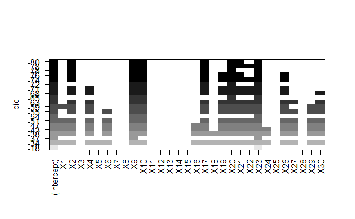

```r
plot(regsubsets(y ~ ., nvmax = 20, data=X))
```

### Methologie générale d’apprentissage d’un modèle

Pour chaque modèle, afin de construire un estimateur sans biais de l’erreur sur l’echantillon, nous utilisons la méthode de l’ensemble de validation qui consiste à partitionner aléatoirement l’échantion en un ensemble d’apprentissage et un ensemble de test, avec une proportion de 2/3, 1/3. Notre fonction est comme ci-dessous:

```r
split_dataset <- function(dataset, percentage_training_set) {
  training_rows <- sample(1:nrow(dataset),
                          percentage_training_set * nrow(dataset))

  res <- NULL
  res$train_set <- dataset[training_rows, ]
  res$test_set <- dataset[-training_rows, ]

  res
}
```

### Premier méthode: Analysés discriminantes quadratique et lineaire(LDA et QDA)

Supposons qu’il suit conditionnellement une loi normale multidimensionnelle à chaque classe, nous pouvons utiliser LDA et QDA.  
Quand est-il pour notre échantillon ?

```r
library(mvShapiroTest)
```

```r
# nous séparons des individus selon leurs classe 1 ou 2(y = 1 ou 2)
X_class1 = as.matrix(X[X$y == 1, 1:30])
X_class2 = as.matrix(X[X$y == 2, 1:30])
# et puis nous faisons un test de Shapiro (test de loi normal multidimensionnelle)
mvShapiro.Test(X_class1)
```

```
    Generalized Shapiro-Wilk test for Multivariate Normality by Villasenor-Alva and
    Gonzalez-Estrada

data:  X_class1
MVW = 0.98249, p-value = 0.2768
```

```r
mvShapiro.Test(X_class2)
```

```
    Generalized Shapiro-Wilk test for Multivariate Normality by Villasenor-Alva and
    Gonzalez-Estrada

data:  X_class2
MVW = 0.98731, p-value = 0.07145
```

D’après le résultat, nous ne rejettons pas l’hypothese qu’il suit une loi normale multidimensionnelles conditionnellement à la chaque classe.  
Sans hypothese suplementaire sur les distributions conditionnelles nous pouvons appliquer l’analyse discriminante lineaire.(LDA)

```r
library(caret)
```

```r
library(MASS)
attach(X)
```

```r
set.seed(1) #pour obtenir le même résultat
folds <- createFolds(y, k = 10, list = TRUE, returnTrain = FALSE)
error_rates_lda <- matrix(nrow = 10, ncol = 1)
#car on a 10 folds
#using 10-folds cross-validation
for (i in 1:10) {
  #make the folds
  train_df_lda <- as.data.frame(X[-folds[[i]],])
  test_df_lda <- as.data.frame(X[folds[[i]],])

  colnames(train_df_lda)[31] <- "y_lda"
  colnames(test_df_lda)[31] <- "y_lda"

  #training
  model <- lda(y_lda~X2+X9+X10+X17+X20+X23, data = train_df_lda)

  #predict
  lda.pred <- predict(model, newdata = test_df_lda)

  #error_rate
  error_rates_lda[i, ] <- length(which(as.vector(lda.pred$class) != as.vector(test_df_lda$y_lda)))/length(as.vector(test_df_lda$y_lda))
}
print(mean(as.vector(error_rates_lda))) # tout 0.22 que les xi 0.2
```

```
[1] 0.2
```

Mais nous ne savons pas si l’analyse discriminante lineaire suffisant ou pas, car ici nous suppons que la matrice de variance est commune pour toutes les classes(hypothese d’homoscedasticite).  
Nous devons vérifier si c’est le cas.

```r
# nous calculons l'erreur moyenne entre les éléments des matrices de variance pour les deux classes
sum(abs(var(X_class1) - var(X_class2))) / 30
```

```
[1] 3.531246
```

Mais nous ne sommes pas sur que l’hypothese d’homoscedasticite est correct si nous ne faisons pas un meilleur test. Si on fait le QDA:

```r
error_rates = matrix(nrow=10, ncol=1)
# using 10-folds cross-validation
for (i in 1:10) {

  # make the folds
  train_df_qda = as.data.frame(X[-folds[[i]],])
  test_df_qda = as.data.frame(X[folds[[i]],])
  colnames(train_df_qda)[31] = "y_qda"
  colnames(test_df_qda)[31] = "y_qda"

  # training
  model = qda(y_qda~X2+X9+X10+X17+X20+X23 , data = train_df_qda)

  # predict
  qda.pred = predict(model, newdata = test_df_qda)

  # error rate
  error_rates[i,] = length(which(
    as.vector(qda.pred$class) != as.vector(test_df_qda$y_qda)
  ))/length(as.vector(test_df_qda$y_qda))
}
mean(as.vector(error_rates))   # 1.Pour tous les vbs 0.295  2.que les vbs significatifs 0.235
```

```
[1] 0.235
```

Ici, nous avons appliqué la fonction QDA sur tous les variables, et l’erreur est 0.295, en même temps nous avons pris les mêmes données en appiquant le QDA seulement sur les xi plus significatifs, l’erreur est 0.235. Le QDA aussi, il fonctionne mieux avec les xi sélectionnés.

Nous allons étudier l’indépendance des variables, s’ils sont indépendants, nous pouvons appliquer le classifieur bayesien naif.

[figure not shown]

```r
corrgram(X_class1)
```

[figure not shown]

```r
corrgram(X_class2)
```

Nous pouvons voir le graphique, cette hypothèse semble clairement non recevable car les variables sont corrélés. Dans ce cas là, nous pouvons appliquer le scale sur les variables. Pour réduire le taille de rapport, ici nous rendrons pas le détail, d’après résultat, nous trouvons que c’est toujours pas le cas pour appliquer le classifieur bayesien naif.

[figure not shown]

```r
SX_class1 = scale(as.matrix(X[X$y == 1, 1:30]))
SX_class2 = scale(as.matrix(X[X$y == 2, 1:30]))
corrgram(SX_class1)
```

[figure not shown]

```r
corrgram(SX_class2)
```

### Deuxième méthode: Utiliser une forêt aléatoire de décision binaire

Pour réduire l’erreur sur les données, nous utilisons une foret aléatoire d’arbres de decision.

```r
library("randomForest")
```

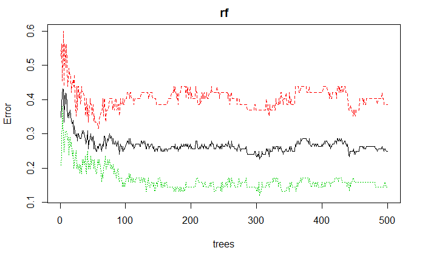

```r
#X <- read.table('tp3_clas_app.txt', header = TRUE)
X$y <- as.factor(X$y)
res <- split_dataset(X, 2 / 3)#nous utilisons la fonction définise avant
train_set <- res$train_set
test_set <- res$test_set
# Creation magique (et naive) de la foret
rf <- randomForest(y ~ ., data = train_set)
plot(rf) # Analyse de l'erreur en fonction de la taille des arbres et du nombre d'arbres
```

```r
#p = dim(train_set)[2]#le nombre de colonnes
#mtry = floor(sqrt(p)) # valeur empirique optimale pour un pbm de classification
#rfopt <- randomForest(y ~ ., data = train_set, ntree = 50, mtry = mtry)
#ntree = 50 selon le graphique
predictions <- predict(rf, newdata = test_set[, 1:30], type = 'class')
erreur <- mean(predictions != test_set$y)
erreur  #  0.1791045
```

```
[1] 0.1791045
```

Nous observons un résultat relativement satisfaisant ( *erreur = 0.1791045*).  
Celui-ci est meilleur car il peut réduire le Test MSE, et est facilement et rapidement interprétable.

### Troisieme idée: regression logistique avec validation croisée

Nous pouvons utiliser la regression logistique pour estimer directement les probabilites d’appartenance à la classe.  
Si nous utilisons seulement la methode de l’ensemble de validation, nous avons obtenu une erreur proche de 0.5, c’est pas bon du tout et c’est pire qu’un modèle de bernouilli.  
Afin de réduire l’erreur, nous utilisons la methode de validation croisée(Cross-Validation) qui consiste à réechantionner plusieurs l’ensemble d’apprentissage pour garder uniquement le meilleur modèle.

```r
library('DAAG')
```

```r
#X <- read.table('tp3_clas_app.txt', header = TRUE)
X$y <- as.factor(X$y)
obj <- glm(y ~ ., data=X, family = binomial(logit))
CVbinary(obj, nfolds=10)
```

```
Fold:  7 1 6 10 9 3 4 2 8 5
Internal estimate of accuracy = 0.865
Cross-validation estimate of accuracy = 0.725
```

### Quatième méthode : KNN

```r
library(class)
error_rates <- matrix(nrow = 50, ncol = 10)
#car on a 50 k et 10 folds?
for(k in 1:50){
  #using 10-folds cross-valisation
  for (i in 1:10) {
    #make the folds
    train_df <- as.data.frame(X[-folds[[i]],])
    test_df <- as.data.frame(X[folds[[i]],])
    colnames(train_df)[31] = "y_df"
    colnames(test_df)[31] = "y_df"

    #knn prediction
    knn.pred <- knn(train_df[, -31], test_df[, -31], train_df$y_df, k = k)

    error_rates[k,i] <- (length(which(as.vector(knn.pred) != as.vector(test_df$y_df)))/length(test_df$y_df))
  }
}
#last prediction confusion table
table(knn.pred, test_df$y_df)
```

```
knn.pred  1  2
       1  2  0
       2  3 15
```

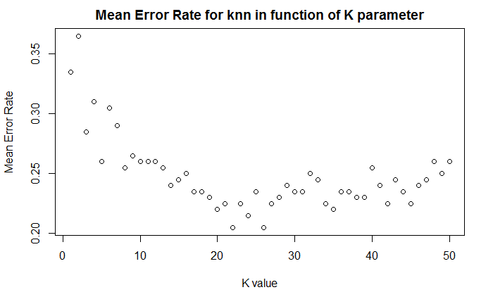

```r
mean_error_rates <- apply(error_rates, 1, mean)
plot(1:50, mean_error_rates, main = "Mean Error Rate for knn in function of K parameter", xlab = "K value", ylab = "Mean Error Rate")
```

```r
mean(mean_error_rates)
```

```
[1] 0.2477
```

Selon le résultat, nous trouvons que l’erreur moyen égale 0.2477.  
Si nous comptons tous les résultats que nous avons obtenu avant:

[output not shown]

D’apres le tableau, nous voyons que le meilleur méthode est Random Forest.

## Regression

### Penser à changer le forme de Xi

```r
Ycarre = data_reg[,-51]^2
Ylog10 = log10(data_reg[,-51])
Ylog2 = log2(data_reg[,-51])
```

```r
newdata_reg = data.frame(data_reg[,-51], Ycarre, Ylog10, Ylog2,data_reg[,51])
colnames(newdata_reg[201]) ="y"
```

```r
min.model = lm(newdata_reg[,201] ~ 1, data=newdata_reg)
biggest <- formula(lm(newdata_reg[,201]~-newdata_reg[,201],newdata_reg))
biggest
```

```
newdata_reg[, 201] ~ -newdata_reg[, 201]
```

```r
fwd.model = step(min.model, direction='forward', scope=biggest)
```

```
Start:  AIC=1124.64
newdata_reg[, 201] ~ 1
```

### Partition des donnés

La première étape de traitement des donnés consiste à réaliser une partition entre donnés d’apprentissage (2/3) et donnés de test (1/3). Nous choisissons ces proportions, qui sont couramment utilisés. Ainsi, seules les donnés d’apprentissage seront utilisés pour regression, tandis que les donnés de test serviront à aluer la performance du modèle.

### Subset selection

Nous commencons par définir la fonction qui nous permettra d’extraire les meilleurs sous-ensembles de préicteurs. Cette fonction est appliqué au donnés d’apprentissage.

```r
getSubsets <- function(formula, train_data, main = '', xlab = '', ylab = ''){
  reg.fit_only_means = regsubsets(formula, data = train_data, really.big = TRUE)
  pdf("./pdf/r2.pdf")
  plot(reg.fit_only_means, scale = "r2", main = main, xlab = xlab, ylab = ylab + ' r2')
  dev.off()
  pdf("./pdf/adjr2.pdf")
  plot(reg.fit_only_means, scale = "adjr2", main = main, xlab = xlab, ylab = ylab + ' adjr2')
  dev.off()
  pdf("./pdf/bic.pdf")
  plot(reg.fit_only_means, scale = "bic", main = main, xlab = xlab, ylab = ylab + ' bic')
  dev.off()
  pdf("./pdf/Cp.pdf")
  plot(reg.fit_only_means, scale = "Cp", main = main, xlab = xlab, ylab = ylab + ' Cp')
  dev.off()
  summary.out <- summary(reg.fit_only_means)
  as.data.frame(summary.out$outmat)
  return(reg.fit_only_means)
}
wholedata.subsets <- getSubsets(y~., data_train, 'Subset Selection for 2/3rds of whole set', 'Predictors', 'Values')
```

### Cross Validation

```r
crossValidate <-function(formula, data, k = 10){
n <- nrow(data)
  folds <- sample(1:k, n, replace = TRUE)
  cv <- 0
  for(k in 1:k){
    reg <- lm(formula, data = data[folds != k,])
    pred <- predict(reg, newdata = data[folds == k,])
    cv <- cv + sum((data$y[folds == k] - pred)^2)
  }
  cv <- cv/n
  return(cv)
}
```

```r
resultat = plot_cross_validations(5)  #find the moyen pour les 4 cols
print(mean(resultat$`adjusted r^2`))
```

```
[1] 124.605
```

```r
print(mean(resultat$bic))
```

```
[1] 124.6405
```

```r
print(mean(resultat$cp))
```

```
[1] 125.1447
```

### Regularisation

```r
x <- model.matrix(y~., data_reg)
y<-as.data.frame(data_reg$y)

set.seed(1)

xapp <- x[train, ]
yapp <- y[train, ]

xtst <- x[-train, ]
ytst <- y[-train, ]
```

#### Lasso

```r
cv.out_lasso <- cv.glmnet(xapp,yapp,alpha=1)
pdf("./pdf/cv.out_lasso.pdf")
plot(cv.out_lasso)
dev.off()
bestlam_lasso=cv.out_lasso$lambda.min
fit.lasso<-glmnet(xapp,yapp,lambda = bestlam_lasso,alpha = 1)
lasso.pred<-predict(fit.lasso, s = cv.out_lasso$lambda.min, newx = xtst)

#calcul MSE
print(mean((ytst-lasso.pred)^2))
```

[output not shown]

#### Ridge

```r
library(glmnet)
cv.out_ridge <- cv.glmnet(xapp, yapp, alpha = 0,parallel=TRUE)
pdf("./pdf/cv.out_ridge.pdf")
plot(cv.out_ridge)
dev.off()
bestlam_ridge=cv.out_ridge$lambda.min
fit.ridge<-glmnet(xapp,yapp,lambda = bestlam_ridge,alpha = 0)
ridge.pred <- predict(fit.ridge, s = cv.out_ridge$lambda.min, newx = xtst)
summary(ridge.pred)

#calcul de MSE
print(mean((ytst-ridge.pred)^2))
```

[output not shown]

Si nous comptons tous les résultats que nous avons obtenu avant:

[output not shown]

Nous voyons bien que le ‘lasso’ est le meilleur!